# Power function growth model for tilapia

PURA acuicultura

2/28/2021

## Introduction

Previously we fit and power function growth model to experimental data concerning the growth of tilapia as a function of time. Here we take the estimates from that exercise and apply them to predictive models incorporating factors such as temperature and feeding. We also expand from singular models of individual fish to complex populations composed of inter-related families. Load the following libraries to get started.

```r
library(tidyverse)
library(gridExtra)
```

## Generating some data

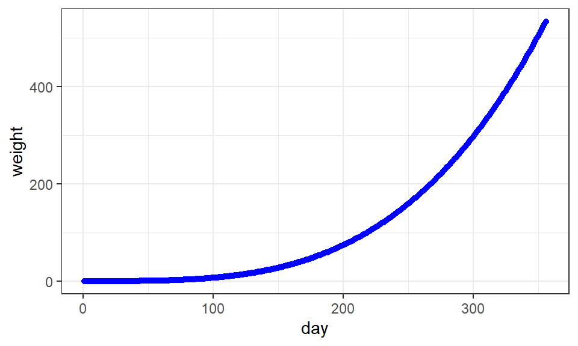

```r
a <- 0.00000092145
b <- 3.43456

day <- seq(1, 356, 1)
weight <- a*day^b
df <- data.frame(day, weight)

df %>% ggplot() +
  geom_point(aes(x = day, y = weight), color = "blue") +
  theme_bw()
```

## Preliminary thoughts on the addition of ‘error’

Our initial curve is perfect, too perfect in fact. We could simply add some error here but this is not really appropriate for a growth model. The following code adds a bit of random error to the curve and produces a plot. This type of error would be fine for models such as temperature as a function of time. For a growth model then, what is the problem?

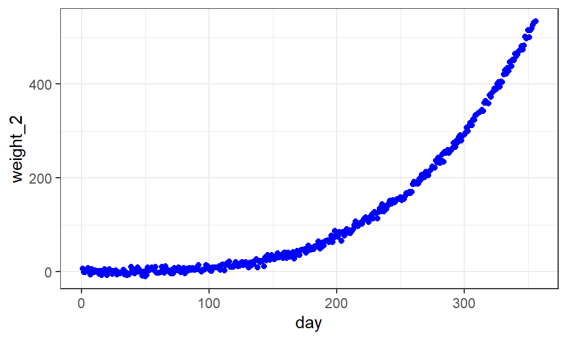

```r
df %>%
  mutate(error = rnorm(356, 0, 5)) %>%
  mutate(weight_2 = weight + error) %>%
  ggplot() +
  geom_point(aes(x = day, y = weight_2), color = "blue") +
  theme_bw()
```

One aspect of growth models that make them different from other time series is that weight losses are not generally of the same magnitude as weight gains. In fact, if this were not true, the organism would not actually be ‘growing’. In our growth model, we need to remember that daily weight accumulates from one day to the next. This accumulation of weight creates a second problem for the constant error term we just added. Relative to their weight, small fish exhibit large errors in weight and large fish small error. This is definitely not a good model. To fix both of these problems we need to hold off on adding error here and convert our model to a more dynamic cumulative growth function.

## Re-parameterization for cumulative growth modeling

Our current model can only account for ‘lifetime’ effects through the exponent ‘b’. In fact, our attempt to add error in the preceding section failed because the magnitude varies on a finer scale. Here we will re-parameterize our existing data to produce a model that can account for ‘daily’ effects. This will not only be useful for error, but any parameter that varies from day-to-day. For example, while feeding and temperature can be modeled with ‘lifetime’ means and/or sums, a model accounting for day-to-day variation in these variables will be significantly more dynamic.

As input, our cumulative growth model takes an initial weight at the start of the day, uses the initial weight to predict weight gain for the day, and then adds weight gain to the initial weight to predict the initial weight of the following day. To create the model we need to re-parameterize our data as ‘weight gain as a function of fish weight’. The result is the same as a Gulland-Holt plot, but in units of weight instead of length (NB: this is an interesting discussion in itself).

The following script updates our data frame with the new parameters through the `mutate()` function. First, the ‘change in weight’ between successive days is calculated as `delta_w`. The `lag()` function is extremely useful in this operation. For each observation (NB: row), weight is subtracted by the weight of the observation that ‘lags’ a specified number of observations (NB: 1 in this case) above it. You can imagine that the first operation results in an NA because it lacks lagging observations. Here we simply drop the first row using the `drop_na` function. After ‘change in weight’, ‘change in day’ is calculated in the same way and given the name `delta_d`. For this model the calculation is really just for consistency given ‘change in day’ will be 1 for all cases, but the calculation can become useful for other instances. Next, ‘weight gain’ is calculated as `delta_w` divided by `delta_d` and given the name `delta_g`. As a final step, the average weight of each successive day interval is calculated and given the name `weight_a`.

With all the new parameters written into the data frame, a plot of ‘weight gain as a function of average weight’ is produced.

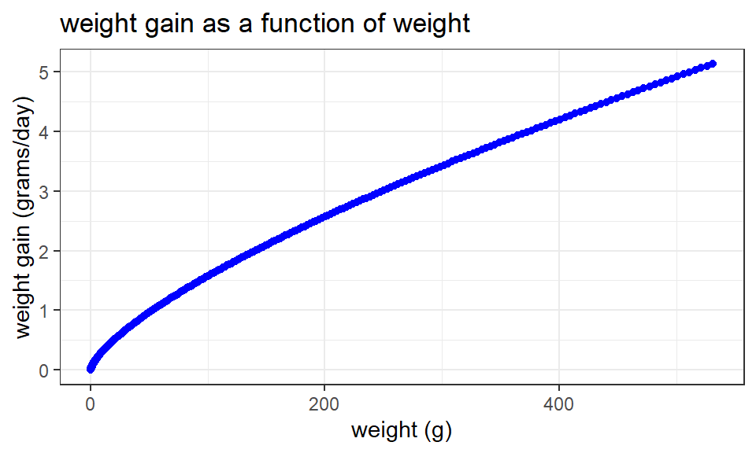

```r
df <- df %>%
  mutate(delta_w = weight - lag(weight, 1)) %>%
  mutate(delta_d = day - lag(day, 1)) %>%
  mutate(delta_g = delta_w / delta_d) %>%
  mutate(weight_a = (weight + lag(weight, 1))/2) %>%
  drop_na()

df %>% ggplot() +
  geom_point(aes(x = weight_a, y = delta_g), color = 'blue') +
  labs(title = "weight gain as a function of weight") +
  labs(x = "weight (g)",
       y = "weight gain (grams/day)") +
  theme_bw()
```

The re-parameterized plot is very different from the one we started with. We can see that ‘weight gain’ increases with average weight in a curvi-linear manner. When measures of length are used to make a Gulland-Holt plot the resulting relationship is linear, and as such, extremely useful in estimating growth parameters and size maximums. Working with weights is not as straight forward, but we can fit a slightly more complex model to our data nonetheless.

## Fit a model to the re-parameterized data

In the following code we fit a linear model to our re-parameterized data by performing a log transformation of both ‘weight gain’ and ‘average weight’. From the coefficients we then make a function called `dwg()` that takes ‘initial weight’ as an input and returns ‘daily weight gain’. To test the function we make an array of initial weights from 0 to 500 and use `sapply()` to determine ‘daily weight gain’ for each initial weight using `dwg()`. By graphing our results for daily weight gain against the array of initial weights we reproduce the preceding plot from which the model was developed. This is simply verification that we did everything correctly.

```r
fit <- lm(log(delta_w) ~ log(weight_a), data = df)
coef(fit)
```

```
##   (Intercept) log(weight_a)
##    -2.8185610     0.7104807
```

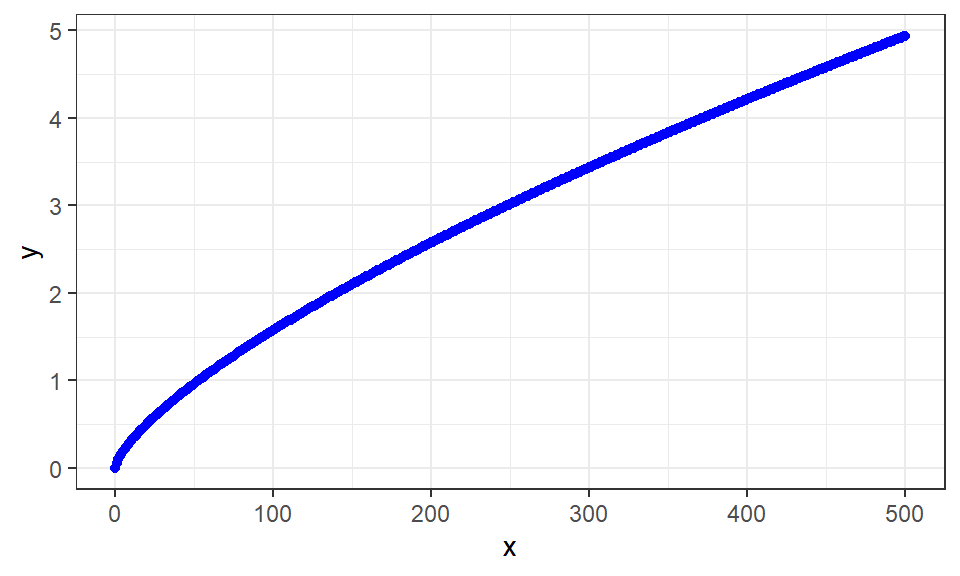

```r
cwg <- function(w_init){
          exp(-2.818561 + 0.7104807 * log(w_init))
          }

x <- seq(0, 500, by = 1)
y <- as.array(sapply(x, FUN = cwg))
df_1 <- data.frame(x, y)

df_1 %>%
  ggplot() +
  geom_point(aes(x = x, y = y), color = 'blue') +
  theme_bw()
```

## Re-create the power function model using a cumulative growth function

We are now going to apply the `dwg()` function sequentially to all the days in a year. We will start with the day 1 weight from out power function model, apply the `dwg()` function, and add ‘daily weight gain’ to the ‘initial weight’ to determine the ‘initial weight’ for the following day. The entire process will then get repeated 356 times. If our equations are correct, we will reproduce the ‘weight as a function of day’ relationship of the original power function.

This ‘cumulative growth function’ will be accomplished using a `for loop`. Creating a `for loop` in R is pretty straightforward process though generally avoided when an `apply()` family function can be used. I have personally never been able to apply other functions aside from `for loops` when ‘iterating’, as we are doing here. Nonetheless, I am sure someone has worked out a more efficient way to do this.

Before starting a `for loop` we need to define a location and format in which the results of the loop will be stored. The following code accomplishes this by first defining our ‘days of growth’ as `dog` and then making an empty vector the same length as `dog`. We call the vector ‘cumulative weight’ or `w_cum` for short. We then add the day 1 weight from out power function model to the first position of the array. Defining the for loop is now quite simple. The loop runs from 1 to `dog`, or 1 to 356 iterations in this case. At each iteration, the `w_cum` array is queried for the iteration number to return the initial weight. The initial weight is then added to the `dwg()` result of the initial weight and added to the `w_cum` one positioned advanced of the iteration number. The loop continues until all iterations have been performed.

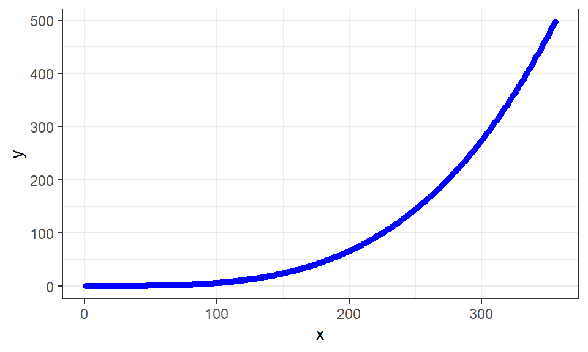

```r
dog <- 356

w_cum <- vector(length = dog)
w_cum[1] <- a*1^b

for(i in 1:dog){
  w_cum[i+1] <- w_cum[i] + cwg(w_cum[i])
}

x <- 1:dog
y <- w_cum[-357]
df_2 <- data.frame(x, y)

df_2 %>%
  ggplot() +
  geom_point(aes(x = x, y = y), color = 'blue') +
  theme_bw()
```

## Add error to the cumulative growth function

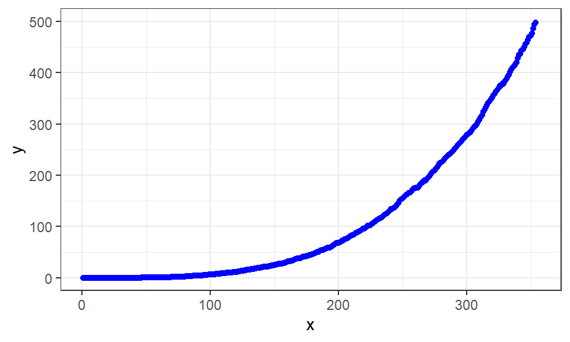

```r
pop <- function(){
  dog <- 356
  w_cum <- vector(length = dog)
  w_cum[1] <- a*1^b

  for(i in 1:dog){
    w_cum[i+1] <- w_cum[i] + cwg(w_cum[i]) * rnorm(1, 1, 0.4)
  }
  w_cum[-357]
}

df_2 <- data.frame(x = 1:356, y = pop())

df_2 %>%
  ggplot() +
  geom_point(aes(x = x, y = y), color = 'blue') +
  ylim(c(0, 500)) +
  theme_bw()
```

## Error leads to individualization

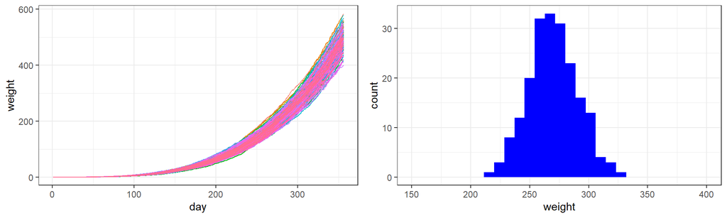

```r
n_pop <- 200

day <- rep(1:356)
weight <- replicate(n_pop, pop())
df_pop <- data.frame(cbind(day, weight))
colnames(df_pop) <- c("day", 1:n_pop)

GC <- df_pop %>%
  gather(key = "fish_id", value = "weight", -day) %>%
  mutate(fish_id = factor(fish_id, levels = as.character(1:n_pop))) %>%
  ggplot() +
  geom_line(aes(x = day, y = weight, color = fish_id)) +
  theme_bw() +
  theme(legend.position = "none")

HIST <- df_pop %>%
  gather(key = "fish_id", value = "weight", -day) %>%
  mutate(fish_id = factor(fish_id, levels = as.character(1:n_pop))) %>%
  filter(day == 300) %>%
  ggplot() +
  geom_histogram(aes(weight), bin.width = 10, fill = 'blue') +
  xlim(c(150, 400)) +
  theme_bw()

grid.arrange(GC, HIST, nrow = 1)
```

## Performance can be manipulated through the same process